# Exploring the BRFSS data

## Setup

### Load packages

```r
library(ggplot2)
library(dplyr)
```

### Load data

Make sure your data and R Markdown files are in the same directory. When loaded your data file will be called `brfss2013`. Delete this note when before you submit your work.

```r
load("brfss2013_truncate.RData")

dim(brfss2013_truncate)
```

```
## [1] 491775     56
```

```r
dimnames(brfss2013_truncate)
```

[output not shown]

[output cut: 11110 more lines]

```r
dim(brfss2013_truncate)
```

```
## [1] 491775     56
```

## Part 1: Data

According to the The Behavioral Risk Factor Surveillance System (BRFSS) website, data is collected from 50 states and 3 US territories in USA via telephone. Surveys are done on adults 18 years-olds.  
Description of each individual columns can be found on *<brfss_codebook.html>*. I used this webpage to get a better understanding of dataset and select the appropriate data from it for my project.

## Part 2: Research questions

**Research quesion 1:** Which state has the highest asthma cases in ratio/percentage? Is the ranking in asthmatic cases consistent over recent years? Possible Reasons for high rate of asthmatic patients.

Asthma is relatively common illness. I wish to find out which states top the list in asthma cases in terms of sample ration in dataset. We can then do more research on why higher rate of asthma cases in the area.

**Research quesion 2:** Does being overweight results in higher probability in heart attack? Does obese people exercise less frequently?

Being overweight is a health problem brough by ourselves. I wish the dataset would tell us overweight is a health problem we can solve by doing exercise regularly.

**Research quesion 3:** Does low income level affect people from getting healthcare covreage? Does low income level restrict people from getting proper medications?

I believe poor people should also have adequate form of healthcare coerage. I would like to see from plots if there is trend that people from lower income group have lower healthecare coerage and wish to highloight it from my findings in the dataset.

## Part 3: Exploratory data analysis

NOTE: Insert code chunks as needed by clicking on the “Insert a new code chunk” button (green button with orange arrow) above. Make sure that your code is visible in the project you submit. Delete this note when before you submit your work.

**Research quesion 1:** Which state has the highest asthma cases in ratio/percentage? Is the ranking in asthmatic cases consistent over recent years? Possible Reasons for high rate of asthmatic patients.

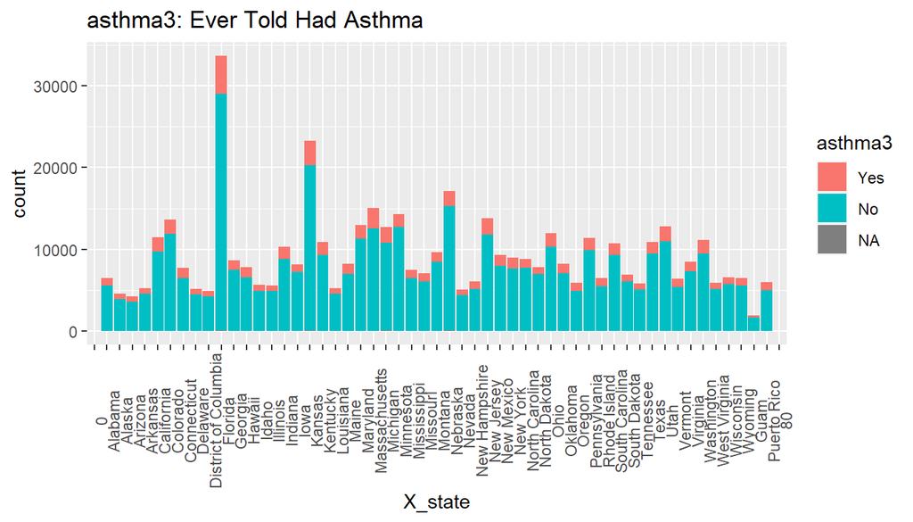

```r
# To find out which state has the highest asthma rate ratio.

# asthma3: Ever Told Had Asthma

ggplot(data=brfss2013_truncate, aes(x = X_state, fill = asthma3)) +
  geom_bar() +
  labs(title = "asthma3: Ever Told Had Asthma") +
  theme(axis.text.x = element_text(angle=90))
```

```r
# As each state has different sample sizes, this plot is hard to tell which state fare better than
# others in terms of asthmaic patients
# A better appproach is to calculate ratio of Yes/No for each state.
```

```r
# List the state name in column 'X_state'
unique(brfss2013_truncate$X_state)
```

```
##  [1] Alabama              Alaska               Arizona
##  [4] Arkansas             California           Colorado
##  [7] Connecticut          Delaware             District of Columbia
## [10] Florida              80                   Georgia
## [13] Hawaii               Idaho                Illinois
## [16] Indiana              Iowa                 Kansas
## [19] Kentucky             Louisiana            Maine
## [22] Maryland             Massachusetts        Michigan
## [25] 0                    Minnesota            Mississippi
## [28] Missouri             Montana              Nebraska
## [31] Nevada               New Hampshire        New Jersey
## [34] New Mexico           New York             North Carolina
## [37] North Dakota         Ohio                 Oklahoma
## [40] Oregon               Pennsylvania         Rhode Island
## [43] South Carolina       South Dakota         Tennessee
## [46] Texas                Utah                 Vermont
## [49] Virginia             Washington           West Virginia
## [52] Wisconsin            Wyoming              Guam
## [55] Puerto Rico
## 55 Levels: 0 Alabama Alaska Arizona Arkansas California ... 80
```

```r
# Data cleaning:
# Need to exclude the '0' and '80' from X_state column, which has no meaning in state name

df <- brfss2013_truncate %>% filter(!X_state %in% c(0,80))

dim(df) # Check 2 unwanted rows are deleted
```

```
## [1] 491773     56
```

```r
# List again the state name in column 'X_state' after remove unwanted rows
unique(df$X_state)
```

```
##  [1] Alabama              Alaska               Arizona
##  [4] Arkansas             California           Colorado
##  [7] Connecticut          Delaware             District of Columbia
## [10] Florida              Georgia              Hawaii
## [13] Idaho                Illinois             Indiana
## [16] Iowa                 Kansas               Kentucky
## [19] Louisiana            Maine                Maryland
## [22] Massachusetts        Michigan             Minnesota
## [25] Mississippi          Missouri             Montana
## [28] Nebraska             Nevada               New Hampshire
## [31] New Jersey           New Mexico           New York
## [34] North Carolina       North Dakota         Ohio
## [37] Oklahoma             Oregon               Pennsylvania
## [40] Rhode Island         South Carolina       South Dakota
## [43] Tennessee            Texas                Utah
## [46] Vermont              Virginia             Washington
## [49] West Virginia        Wisconsin            Wyoming
## [52] Guam                 Puerto Rico
## 55 Levels: 0 Alabama Alaska Arizona Arkansas California ... 80
```

```r
# asthma3: Ever Told Had Asthma

# Count the number of "Yes", "No", & NA in each state.

asthmaYN <- df %>%
  select(X_state, asthma3) %>%
  group_by(X_state, asthma3) %>%
  count() #  <==> summarise(n = sum(asthma3 %in% c("Yes", "No", NA)))

asthmaYN
```

```
## # A tibble: 159 x 3
## # Groups:   X_state, asthma3 [159]
##    X_state  asthma3     n
##    <fct>    <fct>   <int>
##  1 Alabama  Yes       893
##  2 Alabama  No       5591
##  3 Alabama  <NA>       21
##  4 Alaska   Yes       622
##  5 Alaska   No       3942
##  6 Alaska   <NA>       14
##  7 Arizona  Yes       640
##  8 Arizona  No       3596
##  9 Arizona  <NA>       17
## 10 Arkansas Yes       697
## # ... with 149 more rows
```

```r
# Consolidate the "Yes" & "No" into one column each.
# Also create a new column of ratio of YEs/No for each state. This will create a better view when plot.

asthmaYes <- asthmaYN %>% filter(asthma3 == "Yes") %>% rename(stateYes = n)
asthmaYes <- asthmaYes[c("X_state","stateYes")] # Remove column "asthma3"

asthmaNo <- asthmaYN %>% filter(asthma3 == "No") %>% rename(stateNo = n)

asthmaYesNo <- cbind(asthmaYes,
                     stateNo = asthmaNo$stateNo,
                     ratioYes = asthmaYes$stateYes/(asthmaYes$stateYes + asthmaNo$stateNo))

head(asthmaYesNo, n=10)
```

```
## # A tibble: 10 x 4
## # Groups:   X_state [10]
##    X_state              stateYes stateNo ratioYes
##    <fct>                   <int>   <int>    <dbl>
##  1 Alabama                   893    5591    0.138
##  2 Alaska                    622    3942    0.136
##  3 Arizona                   640    3596    0.151
##  4 Arkansas                  697    4551    0.133
##  5 California               1773    9727    0.154
##  6 Colorado                 1747   11861    0.128
##  7 Connecticut              1256    6425    0.164
##  8 Delaware                  740    4448    0.143
##  9 District of Columbia      702    4216    0.143
## 10 Florida                  4627   28930    0.138
```

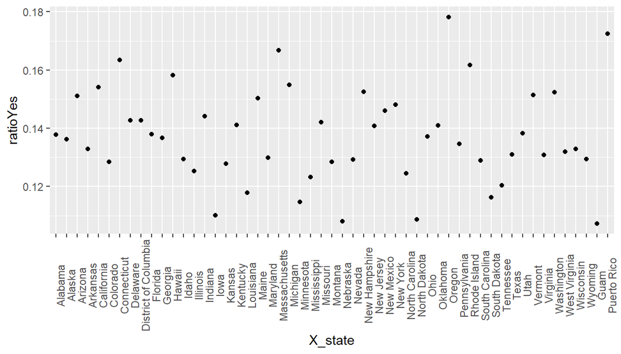

```r
ggplot(data = asthmaYesNo, aes(x= X_state, y =ratioYes)) +
  geom_point() +
  theme(axis.text.x = element_text(angle=90))
```